# Exploring TA Grading Patterns

Andrea Malek Ash

12/6/2020

Load required packages.

```r
if (!require("stats", "psych", "agricolae", "graphics"))install.packages("stats", "psych", "agricolae", "graphics", repos = 'http://cran.us.r-project.org')
library("stats")
library("psych")
library("agricolae")
library("graphics")
```

Load data. Save student scores as csv file (rows = Students, columns = Score, TA)

```r
scores <- read.csv("/Users/andreaash/Student scores.csv", header=TRUE)
scores$TA <- factor(scores$TA) #if your TA identifiers are numeric, this will make them factors
```

Get a summary of each groups’s mean and variance

```r
group.summary <- describeBy(x = scores$Score, group = scores$TA, mat=TRUE) #"mat=TRUE" creates a data frame
print(group.summary)
```

```
##     item group1 vars  n     mean       sd median  trimmed     mad min max range
## X11    1      1    1 89 178.5169 14.89975  175.0 177.7534 13.3434 144 214    70
## X12    2      2    1 22 178.9091 15.28120  180.5 180.3333 14.8260 133 202    69
## X13    3      3    1 92 172.3913 12.57676  172.0 171.8919 14.8260 146 201    55
## X14    4      4    1 29 175.3448 14.63673  175.0 175.7200 17.7912 147 200    53
##           skew   kurtosis       se
## X11  0.4866955 -0.2791554 1.579370
## X12 -1.0423663  1.3695689 3.257963
## X13  0.2557085 -0.5222357 1.311218
## X14 -0.0889932 -1.1226152 2.717973
```

Make a boxplot to visualize your data and get a sense of the difference between TA’s

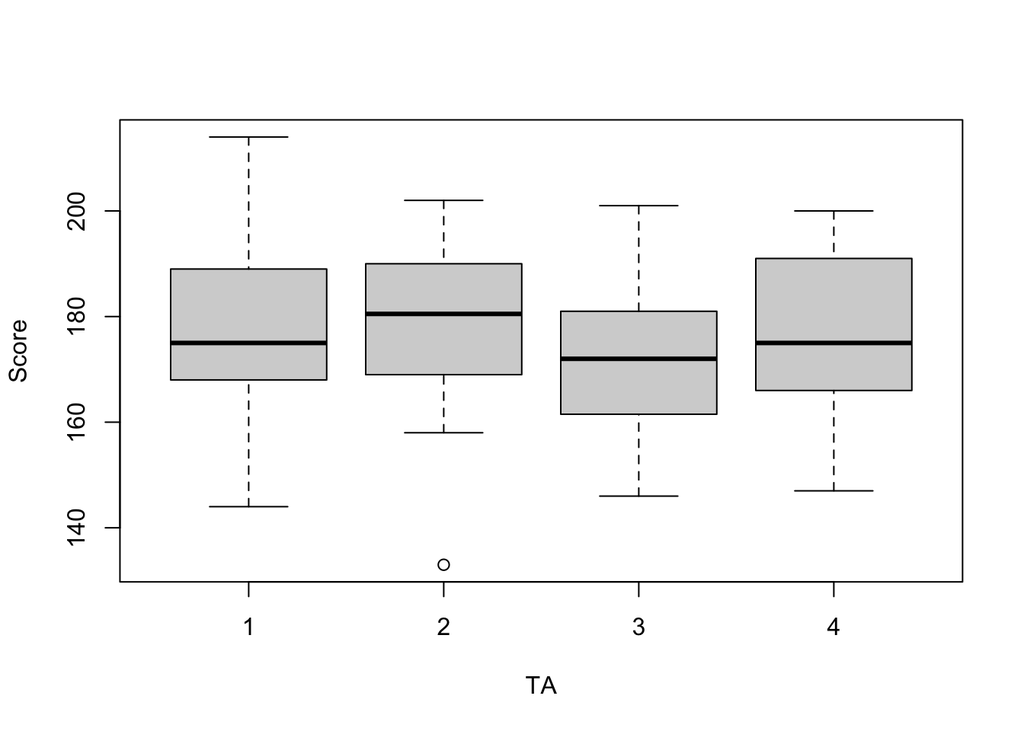

```r
boxplot(Score ~ TA, data = scores)
```

Use a simple ANOVA to compare groups of students graded by the same TA

```r
model.TA <- aov(Score ~ TA, data= scores)
```

Checking ANOVA assumptions and possible problem spots

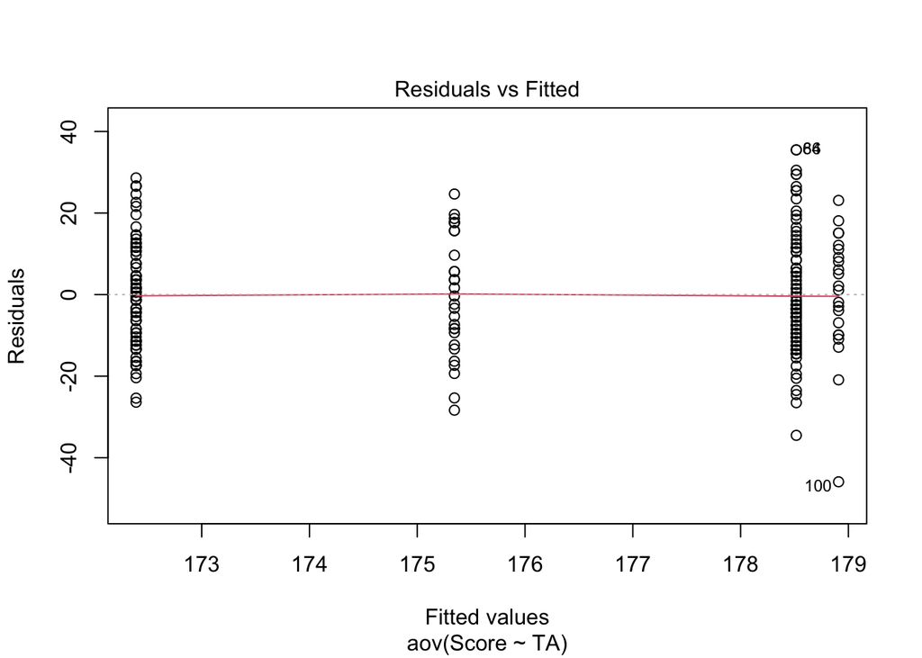

```r
plot(model.TA,1) #Homogeneity of variance - do some score groups vary more widely than others?
```

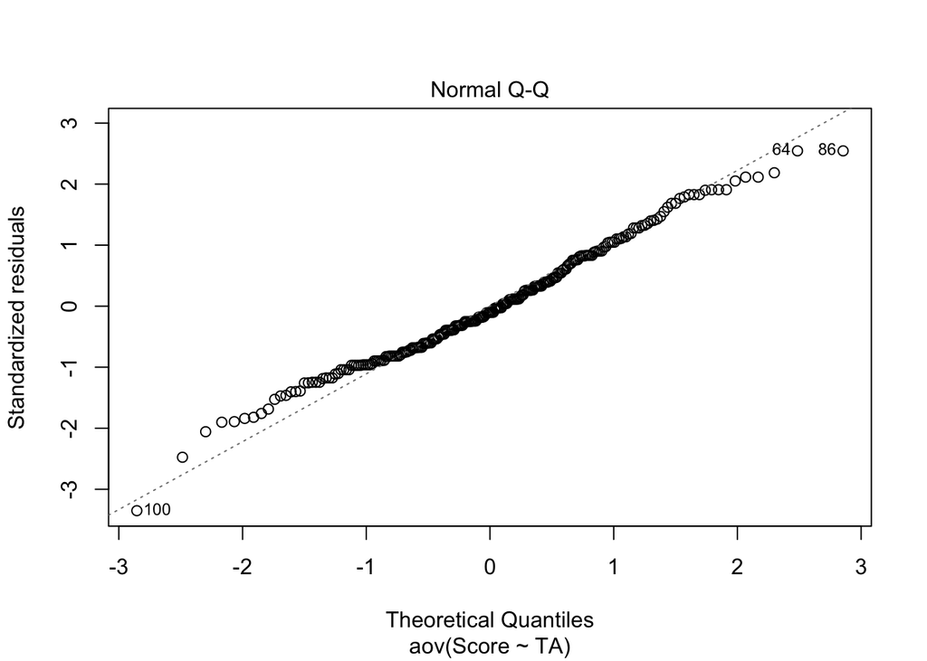

```r
plot(model.TA,2) #Normality of score distribution -  check whether the data are normally distributed.
```

ANOVA is fairly robust to violations of homogeneity of variance. Most likely you can use Plot 1 for informational purposes only, to help you understand differences in variance between groups.

If scores are not normal (likely in course grading!)

```r
skewness(scores$Score) #Check existing skewness of score distribution
```

```
## [1] 0.2403181
```

```r
scores$Score.log10 <- log10(scores$Score) #Use a transformation of your choosing (log10 is used here)
skewness(scores$Score.log10) #Check the skewness again - if improved and the transformation makes sense, use this transformed value as your dependent value in the ANOVA
```

```
## [1] 0.004507981
```

Repeat the ANOVA with new outcome variable, if you’d like.

```r
model.TA.log10 <- aov(Score.log10 ~ TA, data= scores)
```

Remember that TA’s are still confounded with student groups - you can’t interpret a TA effect on its own at this point.

```r
print(TukeyHSD(x = model.TA))
```

```
##   Tukey multiple comparisons of means
##     95% family-wise confidence level
##
## Fit: aov(formula = Score ~ TA, data = scores)
##
## $TA
##          diff        lwr       upr     p adj
## 2-1  0.392237  -8.248716  9.033190 0.9994188
## 3-1 -6.125550 -11.521362 -0.729737 0.0189571
## 4-1 -3.172026 -10.931879  4.587827 0.7154134
## 3-2 -6.517787 -15.130771  2.095198 0.2069429
## 4-2 -3.564263 -13.825064  6.696537 0.8053485
## 4-3  2.953523  -4.775173 10.682220 0.7558402
```

Remember, group differences could be due to TA’s OR other factors like lab section, lab time, student schedules, etc. We don’t know and can’t interpret this - it’s only for informational purposes to help understand patterns in the data.